# Brexit poll analysis

Create june_polls and count the number of rows with the following code:

```r
june_polls <- brexit_polls %>%
              filter(enddate >= "2016-06-01")
    nrow(june_polls)
```

```
[1] 32
```

What proportion of polls have a confidence interval that covers the value 0?

Answer code

```r
 june_polls <- june_polls %>%
              mutate(se_x_hat = sqrt(x_hat*(1-x_hat)/samplesize),
                     se_spread = 2*se_x_hat,
                     ci_lower_spread = spread - qnorm(0.975)*se_spread,
                     ci_upper_spread = spread + qnorm(0.975)*se_spread)
          mean(june_polls$ci_lower_spread < 0 & june_polls$ci_upper_spread > 0)
```

```
[1] 0.625
```

What proportion of polls predict “Remain” (confidence interval entirely above 0)?

Answer code

```r
          mean(june_polls$ci_lower_spread > 0)
```

```
[1] 0.125
```

Answer code

```r
june_polls <- june_polls %>%
    mutate(hit = (2*p-1 > ci_lower_spread) & (2*p-1 < ci_upper_spread))
    mean(june_polls$hit)
```

```
[1] 0.562
```

Question 7: Combined spread across poll type 0.0/2.0 points (graded) Calculate the confidence intervals of the spread combined across all polls in june_polls, grouping by poll type. Recall that to determine the standard error of the spread, you will need to double the standard error of the estimate.

Use this code (which determines the total sample size per poll type, gives each spread estimate a weight based on the poll’s sample size, and adds an estimate of p from the combined spread) to begin your analysis:

```r
combined_by_type <- june_polls %>%
        group_by(poll_type) %>%
        summarize(N = sum(samplesize),
                  spread = sum(spread*samplesize)/N,
                  p_hat = (spread + 1)/2)
```

What is the lower bound of the 95% confidence interval for online voters?

```r
  combined_by_type <- june_polls %>%
    group_by(poll_type) %>%
    summarize(N = sum(samplesize),
              spread = sum(spread*samplesize)/N,
              p_hat = (spread + 1)/2,
              se_spread = 2*sqrt(p_hat*(1-p_hat)/N),
              spread_lower = spread - qnorm(.975)*se_spread,
              spread_upper = spread + qnorm(.975)*se_spread)
combined_by_type %>%
    filter(poll_type == "Online") %>%
    pull(spread_lower)
```

```
[1] -0.0165
```

What is the upper bound of the 95% confidence interval for online voters?

Answer code

```r
  combined_by_type %>%
    filter(poll_type == "Online") %>%
    pull(spread_upper)
```

```
[1] 0.00165
```

Brexit poll analysis - Part 3

Final Assessment due Jun 15, 2021 14:57 +03 This problem set is continued from the previous page. Make sure you have run the following code:

```r
# suggested libraries
library(tidyverse)

# load brexit_polls object and add x_hat column
library(dslabs)
data(brexit_polls)
brexit_polls <- brexit_polls %>%
    mutate(x_hat = (spread + 1)/2)

# final proportion voting "Remain"
p <- 0.481
```

Question 9: Chi-squared p-value 0.0/2.0 points (graded) Define brexit_hit, with the following code, which computes the confidence intervals for all Brexit polls in 2016 and then calculates whether the confidence interval covers the actual value of the spread 𝑑=−0.038:

```r
brexit_hit <- brexit_polls %>%
  mutate(p_hat = (spread + 1)/2,
         se_spread = 2*sqrt(p_hat*(1-p_hat)/samplesize),
         spread_lower = spread - qnorm(.975)*se_spread,
         spread_upper = spread + qnorm(.975)*se_spread,
         hit = spread_lower < -0.038 & spread_upper > -0.038) %>%
  select(poll_type, hit)
```

Use brexit_hit to make a two-by-two table of poll type and hit status. Then use the chisq.test() function to perform a chi-squared test to determine whether the difference in hit rate is significant.

What is the p-value of the chi-squared test comparing the hit rate of online and telephone polls?

Answer code

```r
          brexit_chisq <- table(brexit_hit$poll_type, brexit_hit$hit)
chisq.test(brexit_chisq)$p.value
```

```
[1] 0.00101
```

Determine which poll type has a higher probability of producing a confidence interval that covers the correct value of the spread. Also determine whether this difference is statistically significant at a p-value cutoff of 0.05. Which of the following is true?

Answer code

```r
# online > telephone
hit_rate <- brexit_hit %>%
    group_by(poll_type) %>%
    summarize(avg = mean(hit))
hit_rate$avg[hit_rate$poll_type == "Online"] > hit_rate$avg[hit_rate$poll_type == "Telephone"]
```

```
[1] TRUE
```

```r
# statistically significant
chisq.test(brexit_chisq)$p.value < 0.05
```

```
[1] TRUE
```

Question 10: Odds ratio of online and telephone poll hit rate 0.0/3.0 points (graded) Use the two-by-two table constructed in the previous exercise to calculate the odds ratio between the hit rate of online and telephone polls to determine the magnitude of the difference in performance between the poll types.

Calculate the odds that an online poll generates a confidence interval that covers the actual value of the spread.

Answer code

```r
# from previous question
brexit_chisq <- table(brexit_hit$poll_type, brexit_hit$hit)

# convert to data frame
chisq_df <- as.data.frame(brexit_chisq)

online_true <- chisq_df$Freq[chisq_df$Var1 == "Online" & chisq_df$Var2 == "TRUE"]
online_false <- chisq_df$Freq[chisq_df$Var1 == "Online" & chisq_df$Var2 == "FALSE"]

online_odds <- online_true/online_false
online_odds
```

```
[1] 1.3
```

Calculate the odds that a telephone poll generates a confidence interval that covers the actual value of the spread.

Answer code

```r
phone_true <- chisq_df$Freq[chisq_df$Var1 == "Telephone" & chisq_df$Var2 == "TRUE"]
phone_false <- chisq_df$Freq[chisq_df$Var1 == "Telephone" & chisq_df$Var2 == "FALSE"]

phone_odds <- phone_true/phone_false
phone_odds
```

```
[1] 0.312
```

Calculate the odds ratio to determine how many times larger the odds are for online polls to hit versus telephone polls.

Answer code

```r
online_odds/phone_odds
```

```
[1] 4.15
```

Question 11: Plotting spread over time 1/1 point (graded) Use brexit_polls to make a plot of the spread (spread) over time (enddate) colored by poll type (poll_type). Use geom_smooth() with method = “loess” to plot smooth curves with a span of 0.4. Include the individual data points colored by poll type. Add a horizontal line indicating the final value of 𝑑=−.038.

Which of the following plots is correct?

Answer code

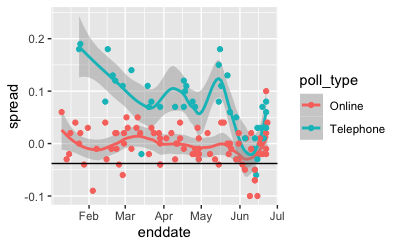

```r
brexit_polls %>%
              ggplot(aes(enddate, spread, color = poll_type)) +
              geom_smooth(method = "loess", span = 0.4) +
              geom_point() +
              geom_hline(aes(yintercept = -.038))
```

Question 12: Plotting raw percentages over time 0.0/2.5 points (graded) Use the following code to create the object brexit_long, which has a column vote containing the three possible votes on a Brexit poll (“remain”, “leave”, “undecided”) and a column proportion containing the raw proportion choosing that vote option on the given poll:

```r
brexit_long <- brexit_polls %>%
    gather(vote, proportion, "remain":"undecided") %>%
    mutate(vote = factor(vote))
```

Make a graph of proportion over time colored by vote. Add a smooth trendline with geom_smooth() and method = “loess” with a span of 0.3.